# National Youth Commission

## 4.3 FY 2025: a one-year tripling

The single most important feature of NYC’s budget is the FY 2025 spike, so it is worth unpacking line by line.

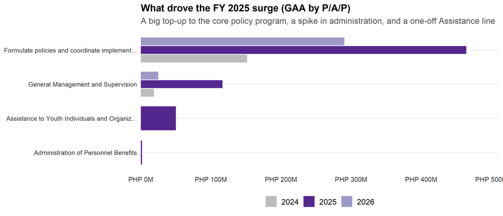

```r
y3 <- pap_year %>% filter(year %in% c(2024, 2025, 2026), !is.na(GAA), GAA > 0) %>%
  mutate(pap = str_trunc(pap, 46), yearf = factor(year))
ord <- y3 %>% filter(year == 2025) %>% arrange(GAA) %>% pull(pap)
y3 <- y3 %>% mutate(pap = factor(pap, levels = unique(c(ord, y3$pap))))
ggplot(y3, aes(pap, GAA, fill = yearf)) +
  geom_col(position = position_dodge(width = 0.75), width = 0.7) + coord_flip() +
  scale_fill_manual(values = c("2024" = "#BDBDBD", "2025" = "#54278F", "2026" = "#9E9AC8")) +
  scale_y_continuous(labels = php_m_axis, expand = expansion(mult = c(0, .1))) +
  labs(title = "What drove the FY 2025 surge (GAA by P/A/P)",
       subtitle = "A big top-up to the core policy program, a spike in administration, and a one-off Assistance line",
       x = NULL, y = NULL) +
  theme_nyc() + theme(axis.text.y = element_text(size = 9, lineheight = 0.9)) +
  guides(fill = guide_legend(nrow = 1))
```

The ₱632M enacted budget for FY 2025 came from three moves, all above the Executive’s ₱242M proposal:

- the core **youth-development policy program jumped to ₱464M** (from ₱152M the year before);
- **General Management** spiked to ₱116M (from ₱18M proposed); and
- a brand-new, one-year-only **“Assistance to Youth Individuals and Organizations”** line appeared at ₱50M.

**FY 2025 was a national election year**, and all three additions receded in the FY 2026 enacted budget. But one change proved durable: the core policy program settled at **₱290M in 2026**, still nearly double its ₱152M level of 2024. So beneath the one-off spike, NYC’s operating program has stepped up — while the extraordinary top-ups came and went with the election cycle.

## 4.4 Where Congress adjusts the budget

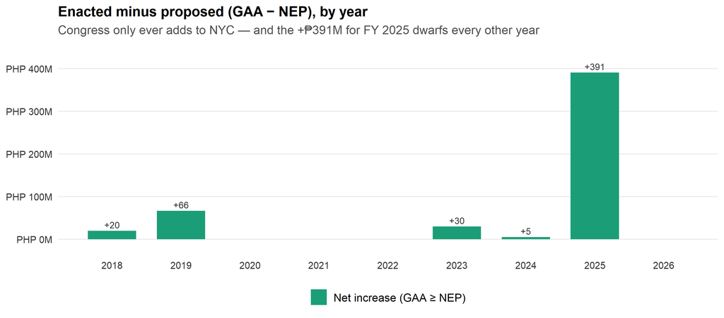

```r
gap <- totals %>% filter(metric %in% c("NEP","GAA")) %>% pivot_wider(names_from = metric, values_from = total) %>%
  mutate(change = GAA - NEP, direction = ifelse(change >= 0, "Net increase (GAA ≥ NEP)", "Net decrease (GAA < NEP)"))
ggplot(gap, aes(year, change/1e6, fill = direction)) +
  geom_col(width = 0.7) +
  geom_text(aes(label = ifelse(abs(change) < 1e5, "", sprintf("%+.0f", change/1e6)),
                vjust = ifelse(change >= 0, -0.4, 1.2)), size = 3.2, color = "grey20") +
  scale_fill_manual(values = c("Net increase (GAA ≥ NEP)" = "#1B9E77", "Net decrease (GAA < NEP)" = "#D95F02")) +
  scale_x_continuous(breaks = 2018:2026) +
  scale_y_continuous(labels = function(v) paste0(peso, v, "M"), expand = expansion(mult = c(0.10, 0.18))) +
  labs(title = "Enacted minus proposed (GAA − NEP), by year",
       subtitle = "Congress only ever adds to NYC — and the +₱391M for FY 2025 dwarfs every other year",
       x = NULL, y = NULL) +
  theme_nyc() + guides(fill = guide_legend(nrow = 1))
```

In every year the enacted budget lands at or above the proposal — Congress **only ever adds** to NYC, never cuts. Most additions are modest (₱5–66M), which makes the **+₱391M for FY 2025** all the more striking: a single-year augmentation larger than the agency’s entire budget in any normal year.

# 5 Where the money goes

## 5.1 Composition by PREXC program

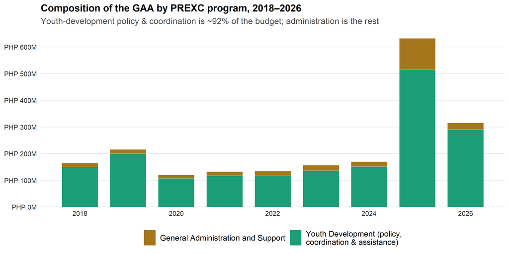

```r
comp <- df_long %>% filter(metric == "GAA", year <= 2026, !is.na(amount), !is.na(category)) %>%
  group_by(year, category) %>% summarise(amount = sum(amount, na.rm = TRUE), .groups = "drop") %>%
  mutate(category = factor(category, levels = names(cat_pal)))
ggplot(comp, aes(year, amount, fill = category)) +
  geom_col(width = 0.75, color = "white", linewidth = 0.2) +
  scale_fill_manual(values = cat_pal, labels = function(x) str_wrap(x, 34)) +
  scale_y_continuous(labels = php_m_axis, breaks = pretty_breaks(6), limits = c(0, NA), expand = expansion(mult = c(0, .05))) +
  scale_x_continuous(breaks = seq(2018, 2026, 2)) +
  labs(title = "Composition of the GAA by PREXC program, 2018–2026",
       subtitle = "Youth-development policy & coordination is ~92% of the budget; administration is the rest",
       x = NULL, y = NULL) +
  theme_nyc() + guides(fill = guide_legend(nrow = 1))
```

The green **Youth Development** program — policy formulation, coordination, and assistance — is essentially the whole agency, around 92% in 2026, with **General Administration and Support** the small remainder. The FY 2025 bulge is visible here too, in both bands: the surge lifted the core program *and* administration before both fell back.

## 5.2 Composition by expense class

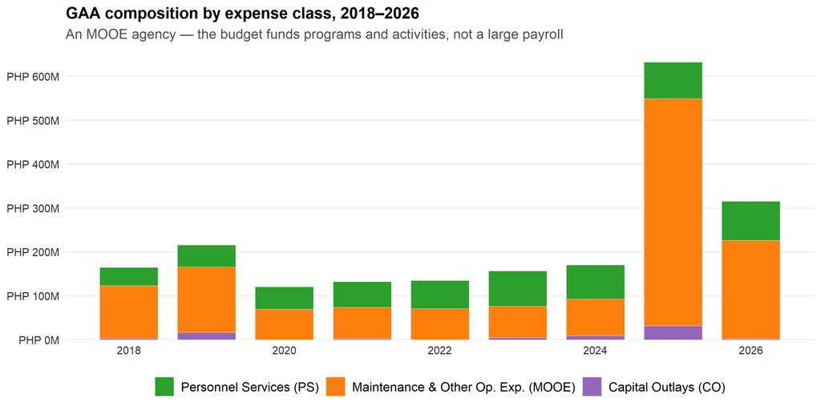

```r
ec_levels <- c("Personnel Services (PS)","Maintenance & Other Op. Exp. (MOOE)","Capital Outlays (CO)")
comp_ec <- df_long_all %>% filter(metric == "GAA", year <= 2026, expense_class %in% c("1PS","2MOOE","6CO")) %>%
  group_by(year, expense_class) %>% summarise(amount = sum(amount, na.rm = TRUE), .groups = "drop") %>%
  mutate(expense_class = factor(expense_class, levels = c("1PS","2MOOE","6CO"), labels = ec_levels))
ggplot(comp_ec, aes(year, amount, fill = expense_class)) +
  geom_col(width = 0.75, color = "white", linewidth = 0.2) +
  scale_fill_manual(values = ec_pal) +
  scale_y_continuous(labels = php_m_axis, breaks = pretty_breaks(6), limits = c(0, NA), expand = expansion(mult = c(0, .05))) +
  scale_x_continuous(breaks = seq(2018, 2026, 2)) +
  labs(title = "GAA composition by expense class, 2018–2026",
       subtitle = "An MOOE agency — the budget funds programs and activities, not a large payroll",
       x = NULL, y = NULL) +
  theme_nyc() + guides(fill = guide_legend(nrow = 1))
```

NYC is an **MOOE agency**: the bulk of its budget is maintenance-and-operating spending — the conferences, programs, grants, coordination, and advocacy that a policy body runs — rather than personnel. The FY 2025 windfall came almost entirely as MOOE, which is part of why it was hard to disburse in a single year.

## 5.3 The largest P/A/Ps

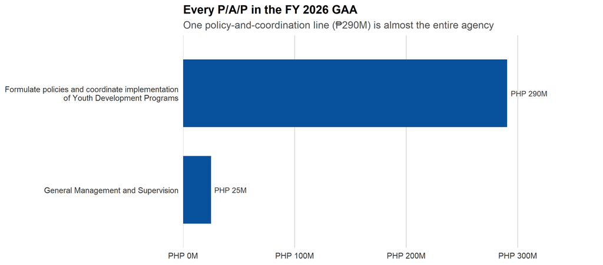

```r
top_paps <- pap_year %>% filter(year == 2026, !is.na(GAA), GAA > 0) %>% arrange(desc(GAA)) %>%
  mutate(pap = factor(pap, levels = rev(pap)))
ggplot(top_paps, aes(pap, GAA)) +
  geom_col(fill = bar_fill, width = 0.7) +
  geom_text(aes(label = php_m(GAA)), hjust = -0.1, size = 3.2, color = "grey20") +
  coord_flip() + scale_x_discrete(labels = function(x) str_wrap(x, 50)) +
  scale_y_continuous(labels = php_m_axis, expand = expansion(mult = c(0, .28)), limits = c(0, NA)) +
  labs(title = "Every P/A/P in the FY 2026 GAA",
       subtitle = "One policy-and-coordination line (₱290M) is almost the entire agency",
       x = NULL, y = NULL) +
  theme_nyc() + theme(panel.grid.major.y = element_blank(), panel.grid.major.x = element_line(color = "grey85"))
```

### Full P/A/P ranking, FY 2026 (interactive)

```r
pap_year %>% filter(year == 2026, !is.na(GAA)) %>%
  left_join(pap_year %>% filter(year == 2025) %>% transmute(pap, GAA25 = GAA), by = "pap") %>%
  transmute(`P/A/P` = pap, `NEP 2026 (M)` = NEP/1e6, `GAA 2026 (M)` = GAA/1e6,
            `GAA 2025 (M)` = GAA25/1e6, `Net add 2026 (M)` = (GAA - NEP)/1e6) %>%
  arrange(desc(`GAA 2026 (M)`)) %>%
  dt_table(page = 10, money_cols = c("NEP 2026 (M)","GAA 2026 (M)","GAA 2025 (M)","Net add 2026 (M)"))
```

| P/A/P | NEP 2026 (M) | GAA 2026 (M) | GAA 2025 (M) | Net add 2026 (M) |
| --- | --- | --- | --- | --- |
| Formulate policies and coordinate implementation of Youth Development Programs | 290.441 | 290.441 | 464.127 | 0 |
| General Management and Supervision | 25.028 | 25.028 | 116.491 | 0 |

# 6 Overall budget utilization

With no program-level execution data, utilization can only be read at the **agency aggregate**, and on a different basis from the appropriations above (all available funds, not just current-year new appropriations). On that basis NYC is a **middling absorber in normal years and a weak one in 2025**.

## 6.1 Execution over time

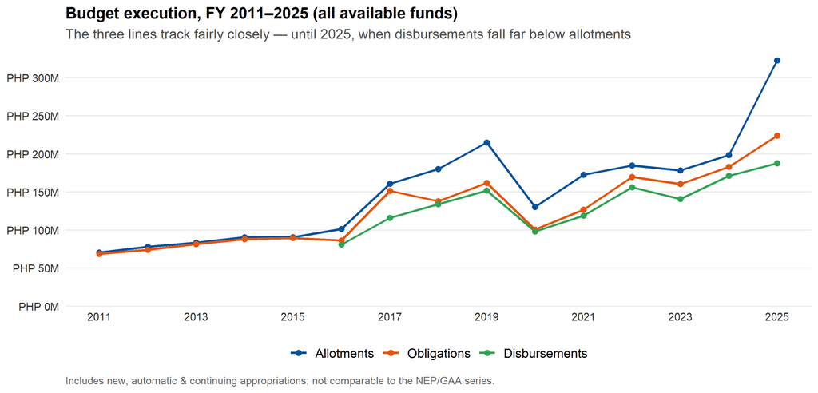

```r
el <- exec %>% select(year, Allotments, Obligations, Disbursements) %>%
  pivot_longer(-year, names_to = "stage", values_to = "amount") %>% filter(!is.na(amount)) %>%
  mutate(stage = factor(stage, levels = c("Allotments","Obligations","Disbursements")))
ggplot(el, aes(year, amount, color = stage, group = stage)) +
  geom_line(linewidth = 1.0) + geom_point(size = 2) +
  scale_color_manual(values = exec_pal) +
  scale_y_continuous(labels = php_m_axis, breaks = pretty_breaks(6), limits = c(0, NA), expand = expansion(mult = c(0, .05))) +
  scale_x_continuous(breaks = seq(2011, 2025, 2)) +
  labs(title = "Budget execution, FY 2011–2025 (all available funds)",
       subtitle = "The three lines track fairly closely — until 2025, when disbursements fall far below allotments",
       x = NULL, y = NULL, caption = "Includes new, automatic & continuing appropriations; not comparable to the NEP/GAA series.") +
  theme_nyc() + guides(color = guide_legend(nrow = 1))
```

For most of the period the three lines move together at a modest level. The exception is **2025**, where allotments jump but disbursements lag far behind — the visible signature of a windfall the agency could not spend within the year.

## 6.2 Absorptive capacity

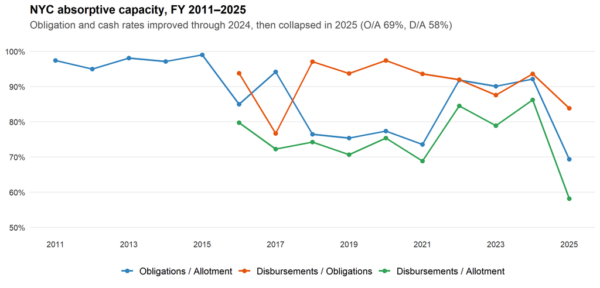

```r
absorp_long <- exec %>% select(year, oblig_allot, disb_oblig, disb_allot) %>%
  pivot_longer(-year, names_to = "ratio", values_to = "value") %>% filter(!is.na(value)) %>%
  mutate(ratio = factor(ratio, levels = c("oblig_allot","disb_oblig","disb_allot"),
    labels = c("Obligations / Allotment","Disbursements / Obligations","Disbursements / Allotment")))
ggplot(absorp_long, aes(year, value, color = ratio, group = ratio)) +
  geom_line(linewidth = 0.9) + geom_point(size = 2) +
  scale_color_manual(values = absorp_pal) +
  scale_y_continuous(labels = percent_format(accuracy = 1), limits = c(0.5, 1.02), breaks = seq(0.5, 1, 0.1)) +
  scale_x_continuous(breaks = seq(2011, 2025, 2)) +
  labs(title = "NYC absorptive capacity, FY 2011–2025",
       subtitle = "Obligation and cash rates improved through 2024, then collapsed in 2025 (O/A 69%, D/A 58%)",
       x = NULL, y = NULL) +
  theme_nyc() + guides(color = guide_legend(nrow = 1))
```

NYC’s absorption had actually been **improving** — disbursement-to-allotment climbed from the low-70s to **86% by 2024**. Then the FY 2025 surge reversed it: obligations fell to **69%** of the allotment and disbursements to just **58%**, the agency’s weakest cash utilization on record. The pattern is telling — NYC can spend a steady budget reasonably well, but a sudden trebling exceeded its capacity to obligate and pay within the year.

### Execution at a glance (interactive)

```r
exec %>% transmute(Year = year, `Allotments (M)` = Allotments/1e6, `Obligations (M)` = Obligations/1e6,
            `Disbursements (M)` = Disbursements/1e6, `O/A` = oblig_allot, `D/O` = disb_oblig, `D/A` = disb_allot) %>%
  dt_table(page = 15, money_cols = c("Allotments (M)","Obligations (M)","Disbursements (M)"),
           pct_cols = c("O/A","D/O","D/A"))
```

| Year | Allotments (M) | Obligations (M) | Disbursements (M) | O/A | D/O | D/A |
| --- | --- | --- | --- | --- | --- | --- |
| 2011 | 70.464 | 68.671 |  | 0.9745543823796549 |  |  |
| 2012 | 78.026 | 74.116 |  | 0.9498884987055597 |  |  |
| 2013 | 83.261 | 81.715 |  | 0.9814318828743349 |  |  |
| 2014 | 90.522 | 87.974 |  | 0.9718521464395395 |  |  |
| 2015 | 90.406 | 89.527 |  | 0.9902771939915492 |  |  |
| 2016 | 101.396 | 86.197 | 80.874 | 0.8501025681486449 | 0.938246110653503 | 0.7976054282220206 |
| 2017 | 160.692 | 151.366 | 116.118 | 0.9419635078286411 | 0.7671339666767967 | 0.7226122022253753 |
| 2018 | 180.364 | 137.934 | 133.945 | 0.7647534984808498 | 0.9710803717720069 | 0.7426371116187266 |
| 2019 | 214.923 | 161.988 | 151.849 | 0.7537024887983138 | 0.9374089438723856 | 0.7065274540184159 |
| 2020 | 130.252 | 100.789 | 98.225 | 0.7738000184258207 | 0.9745607159511455 | 0.7541150999600774 |

[output cut: 5 more lines]

PHP millions, all-funds basis. O/A = obligations ÷ allotment; D/O = disbursements ÷ obligations; D/A = disbursements ÷ allotment. Not comparable to the NEP/GAA appropriations series above.

# 7 Questions for discussion

1. **Is the envelope enough?** At about **₱10 per young Filipino per year**, is NYC funded to be a credible national policy and coordinating body for roughly a third of the population — or only to exist?
2. **Can NYC absorb sudden windfalls?** The FY 2025 surge tripled the budget but only **58% was disbursed**. Was that money well-targeted, and does the agency have the staffing and systems to spend a large increase well?
3. **The one-year Assistance line.** A ₱50M “Assistance to Youth Individuals and Organizations” line appeared for FY 2025 only. What did it fund, who decided the recipients, and why did it not continue?
4. **Reaching youth everywhere.** With ~92% of the budget in one policy-and-coordination line, can young people — especially outside Metro Manila — see which programs actually reach them?
5. **What is missing?** Which youth needs — employment, education, mental health, meaningful participation — does this budget not reach at all?
6. **What would program-level execution data show?** With no FAR No. 1, we can see that NYC’s overall spending lagged in 2025, but not *which* activities stalled. Program-level records would show where a windfall like FY 2025’s actually went — and where it got stuck.

Underlying data: DBM NEP & GAA documents (current-year new appropriations, P/A/P level), FY 2018–2026; DBM-published execution aggregates (all available funds, agency level), FY 2011–2025. Per-person figures use the 2020 Census of Population and Housing (31,400,000 Filipinos aged 15–30, the RA 8044 definition of youth). No FAR No. 1 (P/A/P-level execution) was available for NYC, so absorption is reported only at the agency aggregate, on a basis not directly comparable to the appropriations series. Prepared as the long-form companion to the NYC budget briefing.